# MLRA 111B - Glynwood B-slope Erosion; Northeastern IN

Stephen Roecker and Neil Martin

2017-05-22

# 1 Introduction

This analysis looks at the field data collected for the following 2017 MLRA project: - MLRA 111B - Glynwood B-slope Erosion; Northeastern IN

Spatially disaggregate the existing SSURGO polygons for Glynwood B-slope map units using ArcSIE, in order to separate different soil erosion phases. The current SSURGO maps join issues at the SSA boundaries, due to different erosion phases. This project is deemed relevant due to the current interest in Soil Health. Distinguishing the difference in erosion phases may have minimal impact on the majority of soil interpretations, but is believed to be significant in distinguishing crop yields.

# 2 Data Preparation

```r
library(aqp)
library(soilDB)

library(reshape2)
library(ggplot2)
library(gridExtra)
library(knitr)

library(cluster)
library(caret)
library(party)
library(vegan)

library(rgdal)
library(sp)
library(mapview)
```

## 2.1 Point Data

```r
# projectmapunit data from NASIS
project <- get_projectmapunit_from_NASIS()
project_nodups <- project[!duplicated(project$nationalmusym), c("nationalmusym", "muname")]

# MUPOLYGONs for the Project
gw_pol <- readOGR(dsn = paste0(ownCloud, "glynwood.shp"), layer = "glynwood")

# Soil Survey Areas
ssa <- readOGR(dsn = paste0(geodata, "soils/soilsa_a_nrcs.shp"), layer = "soilsa_a_nrcs")

# Series Extent of Glynwood from SoilWeb
gw_series <- seriesExtent("Glynwood")

# field Data
gw <- read.csv(paste0(ownCloud, "Pts_gnbero_27Jan17.csv"))

gw_sp <- gw
coordinates(gw_sp) <- ~ long + lat
proj4string(gw_sp) <- CRS("+init=epsg:4326")
gw_sp <- spTransform(gw_sp, CRS(proj4string(gw_pol)))

# spatial overlay field data with mupolygons and merge with nasis mapunits
vars <- c("AREASYMBOL", "nationalmu")
gw <- cbind(gw, over(gw_sp, gw_pol)[vars])
gw <- merge(gw, project_nodups, by.x = "nationalmu", by.y = "nationalmusym", all.x = TRUE, sort = FALSE)


# Extract erosion phases from NASIS and combine component and phase
ero_labels <- c("undisturbed", "slight", "moderate", "severe")

gw <- within(gw, {
  EroClassFD  = factor(EroClassFD, levels = 0:3, labels = ero_labels)
  EroClassSIE = factor(EroClassSIE, levels = 0:3, labels = ero_labels)
  EroClassFD2 = ifelse(EroClassFD == "severe", "severe", "slight")

  EroClassNASIS = NA
  EroClassNASIS[grepl("eroded", muname)] = "eroded"
  EroClassNASIS[grepl("sev.|severely", muname)] = "sev.eroded"
  EroClassNASIS[!grepl("eroded", muname)] = "non.eroded"

  soilname2 = soilname
  soilname2 = ifelse(soilname2 %in% c("Glynwood", "Morley", "Shinrock", "Rawson", "Mississinewa"), "Glynwood", soilname2)
  soilname2 = ifelse(soilname2 %in% c("Blount", "Elliott"), "Blount", soilname2)
  soilname2 = ifelse(soilname2 %in% c("Pewamo", "Pandora", "Mermill"), "Pewamo", soilname2)
  soilname3 = paste0(soilname2, ifelse(soilname2 == "Glynwood", paste0("-", EroClassFD2), ""))
  })
gw <- transform(gw,
                rgb = munsell2rgb(mxhue, mxvalue, mxchroma, return_triplets = TRUE)
                )
gw_sp <- gw
coordinates(gw_sp) <- ~ long + lat
proj4string(gw_sp) <- CRS("+init=epsg:4326")
gw_sp <- spTransform(gw_sp, CRS(proj4string(gw_pol)))
```

# 3 Spatial Data

The geodata from the Glynwood points was extracted from several rasters at various resolutions. The data using to generate the ArcSIE model came from a DEM with a resolution of 15-feet. The other used came from the 10-meter USGS NED, which was primarily resampled from LiDAR.

```r
# Extract data from rasters
library(raster)

# NW files
fd <- paste0(geodata, "project_data/11FIN/PointDataEval/")
dd <- c("slope10",
        "procrv10",
        "plncrv10",
        "maxcrv10",
        "mincrv10",
        "relpos_r5",
        "wetness_mp"
        )
fp <- paste0(fd, "Mosaic_NW_pts/Derivatives/", dd, "/", "w001001.adf")
rs <- stack(fp)
names(rs) <- dd
proj4string(rs) <- CRS("+init=epsg:2965")
gd_nw <- extract(rs, gw_sp, df = TRUE, sp = TRUE)@data
gd_nw <- subset(gd_nw, !is.na(slope10))

# SE files
fp <- paste0(fd, "Mosaic_SE_pts/Derivatives/", dd, "/", "w001001.adf")
rs <- stack(fp)
names(rs) <- dd
proj4string(rs) <- CRS("+init=epsg:2965")
gd_se <- extract(rs, gw_sp, df = TRUE, sp = TRUE)@data
gd_se <- subset(gd_se, !is.na(slope10))

gd15ft <- rbind(gd_nw, gd_se)
rm(gd_nw, gd_se)
write.csv(gd15ft, file = paste0(ownCloud, "geodata_15ft_extract.csv"))


# Region 11 files

subset_rasters <- function(input, output) {
  cat(paste0(input, "\n"))
  gdal_translate(
    src_dataset = input,
    dst_dataset = output,
    projwin = c(bb[1,1], bb[2,2], bb[1,2], bb[2,1]),
    of = "GTiff",
    a_nodata = -99999,
    overwrite = TRUE,
    verbose = TRUE
    )
  }

warp_rasters <- function(input, output){
  cat(paste0(input,"\n"))
  gdalwarp(
    srcfile = input,
    dstfile = output,
    te = bb,
    s_srs = CRSargs(CRS("+init=epsg:5070")),
    t_srs = CRSargs(CRS("+init=epsg:5070")),
    r = "bilinear",
    tr = c(10, 10),
    of = "GTiff",
    overwrite = TRUE,
    verbose = TRUE
    )
  }

fd <- paste0(geodata, "project_data/11FIN/sdat/")
dd2 <- c("ned10m_11FIN.sdat",
        "ned10m_11FIN_aspect5.sdat",
        "ned10m_11FIN_slope5.sdat",
        "ned10m_11FIN_cupro5.sdat",
        "ned10m_11FIN_cutan5.sdat",
        "ned30m_11FIN_mvalleys.sdat",
        "ned30m_11FIN_wetness.sdat",
        "ned30m_11FIN_z2stream.sdat",
        "nlcd30m_11FIN_lulc2011.sdat"
        )
dd_names <- c("elev", "aspect5", "slope5", "kp5", "kt5", "mvalley", "wetness2", "z2streams", "lulc")
dd <- paste0(fd, dd2)

input <- dd
output <- paste0(geodata, "project_data/11FIN/glynwood/", gsub(".sdat", ".tif", dd2))
bb <- bbox(gw_sp <- spTransform(gw_sp, CRS("+init=epsg:5070")))

mapply(subset_rasters, input, output)
mapply(subset_rasters, input = paste0(geodata, "project_data/11FIN/nlcd30m_11FIN_lulc2011.tif"), output = paste0(geodata, "project_data/11FIN/glynwood/nlcd30m_11FIN_lulc2011.tif"))

mapply(warp_rasters, input = output, output = gsub(".tif", "2.tif", gsub("30m", "10m", output)))

dd <- output

rs10m <- stack(dd[grepl("10m", dd)])
names(rs10m) <- dd_names[1:5]
rs30m <- stack(dd[grepl("30m", dd)])
names(rs30m) <- dd_names[6:9]

rs10m <- stack(gsub(".tif", "2.tif", gsub("30m", "10m", output)))
names(rs10m) <- dd_names

gw <- as.data.frame(extract(rs10m, gw_sp, df = TRUE, sp = TRUE))
gd30m <- as.data.frame(extract(rs30m, gw_sp, df = TRUE))
gw <- cbind(gd10m, gd30m[, -1])
rm(gd10m, gd30m)


# Save data
save(gw, gw_sp, gw_pol, gw_series, ssa, ero_labels, file = paste0(ownCloud, "Pts_gnbero_27Jan17_geodata.RData"))
```

# 4 Exploratory Analysis of the Project Data

```r
# Load cached dataset
load(paste0(ownCloud, "Pts_gnbero_27Jan17_geodata.RData"))

ssa <- subset(ssa, areasymbol %in% unique(gw$AREASYMBOL))
ssa <- spTransform(ssa, CRS("+init=epsg:4326"))

# Create interactive map
mapView(gw_series) + ssa + gw_sp
```

[interactive chart not shown]

```r
vals2 <- c("EroClassFD", "EroClassNASIS", "nationalmu", "AREASYMBOL")
gw_sub <- gw[vals2]

# Duplicate the data for each REASYMBOL and relabel MLRA
gw_sub2 <- by(gw_sub, gw_sub$nationalmu, function(x) {
  x[vals2][1, ]
  x[, "AREASYMBOL"] <- "MLRA"
  return(x)
  })
gw_sub2 <- do.call("rbind", gw_sub2)
gw_sub <- rbind(gw_sub, gw_sub2)
gw_sub$natmuSsaEro <-  with(gw_sub,
                            paste0(nationalmu, "-", AREASYMBOL, "-", EroClassNASIS)
                            )
test <- xtabs(~ natmuSsaEro + EroClassFD, data = gw_sub)
kable(test, caption = "Frequence by MUSYM-SSA-EROSION")
```

Frequence by MUSYM-SSA-EROSION

|  | undisturbed | slight | moderate | severe |
| --- | --- | --- | --- | --- |
| 2t6ll-IN009-sev.eroded | 6 | 19 | 18 | 3 |
| 2t6ll-IN053-sev.eroded | 3 | 13 | 20 | 11 |
| 2t6ll-IN075-sev.eroded | 6 | 8 | 4 | 5 |
| 2t6ll-MLRA-sev.eroded | 15 | 40 | 42 | 19 |
| 2t6lm-IN009-sev.eroded | 2 | 10 | 10 | 0 |
| 2t6lm-IN053-sev.eroded | 1 | 6 | 8 | 12 |
| 2t6lm-IN075-sev.eroded | 3 | 1 | 11 | 9 |
| 2t6lm-IN179-sev.eroded | 5 | 12 | 0 | 13 |
| 2t6lm-MLRA-sev.eroded | 11 | 29 | 29 | 34 |
| 2v4bn-IN069-eroded | 4 | 3 | 6 | 4 |
| 2v4bn-MLRA-eroded | 4 | 3 | 6 | 4 |
| 2v4bp-IN179-eroded | 0 | 3 | 0 | 2 |
| 2v4bp-MLRA-eroded | 0 | 3 | 0 | 2 |
| 5jjt-IN035-sev.eroded | 1 | 1 | 2 | 9 |
| 5jjt-MLRA-sev.eroded | 1 | 1 | 2 | 9 |
| NA-NA-non.eroded | 6 | 9 | 11 | 22 |

```r
kable(round(prop.table(test, 1) * 100), caption = "Percent by MUSYM-SSA-EROSION")
```

Percent by MUSYM-SSA-EROSION

|  | undisturbed | slight | moderate | severe |
| --- | --- | --- | --- | --- |
| 2t6ll-IN009-sev.eroded | 13 | 41 | 39 | 7 |
| 2t6ll-IN053-sev.eroded | 6 | 28 | 43 | 23 |
| 2t6ll-IN075-sev.eroded | 26 | 35 | 17 | 22 |
| 2t6ll-MLRA-sev.eroded | 13 | 34 | 36 | 16 |
| 2t6lm-IN009-sev.eroded | 9 | 45 | 45 | 0 |
| 2t6lm-IN053-sev.eroded | 4 | 22 | 30 | 44 |
| 2t6lm-IN075-sev.eroded | 12 | 4 | 46 | 38 |
| 2t6lm-IN179-sev.eroded | 17 | 40 | 0 | 43 |
| 2t6lm-MLRA-sev.eroded | 11 | 28 | 28 | 33 |
| 2v4bn-IN069-eroded | 24 | 18 | 35 | 24 |
| 2v4bn-MLRA-eroded | 24 | 18 | 35 | 24 |
| 2v4bp-IN179-eroded | 0 | 60 | 0 | 40 |
| 2v4bp-MLRA-eroded | 0 | 60 | 0 | 40 |
| 5jjt-IN035-sev.eroded | 8 | 8 | 15 | 69 |
| 5jjt-MLRA-sev.eroded | 8 | 8 | 15 | 69 |
| NA-NA-non.eroded | 12 | 19 | 23 | 46 |

Several of counties phased severely eroded, are not dominanted by field observations classified as severely eroded.

# 5 Accuracy Assessment of the ArcSIE Predictions

```r
cm <- confusionMatrix(data = gw$EroClassSIE, reference = gw$EroClassFD)
print(cm)
```

```
## Confusion Matrix and Statistics
##
##              Reference
## Prediction    undisturbed slight moderate severe
##   undisturbed           0      0        0      0
##   slight                6      8       11      9
##   moderate             24     39       53     37
##   severe                7     37       25     44
##
## Overall Statistics
##
##                Accuracy : 0.35
##                  95% CI : (0.2961, 0.4069)
##     No Information Rate : 0.3
##     P-Value [Acc > NIR] : 0.03521
##
##                   Kappa : 0.0767
##  Mcnemar's Test P-Value : 1.555e-13
##
## Statistics by Class:
##
##                      Class: undisturbed Class: slight Class: moderate
## Sensitivity                      0.0000       0.09524          0.5955
## Specificity                      1.0000       0.87963          0.5261
## Pos Pred Value                      NaN       0.23529          0.3464
## Neg Pred Value                   0.8767       0.71429          0.7551
## Prevalence                       0.1233       0.28000          0.2967
## Detection Rate                   0.0000       0.02667          0.1767
## Detection Prevalence             0.0000       0.11333          0.5100
## Balanced Accuracy                0.5000       0.48743          0.5608
##                      Class: severe
## Sensitivity                 0.4889
## Specificity                 0.6714
## Pos Pred Value              0.3894
## Neg Pred Value              0.7540
## Prevalence                  0.3000
## Detection Rate              0.1467
## Detection Prevalence        0.3767
## Balanced Accuracy           0.5802
```

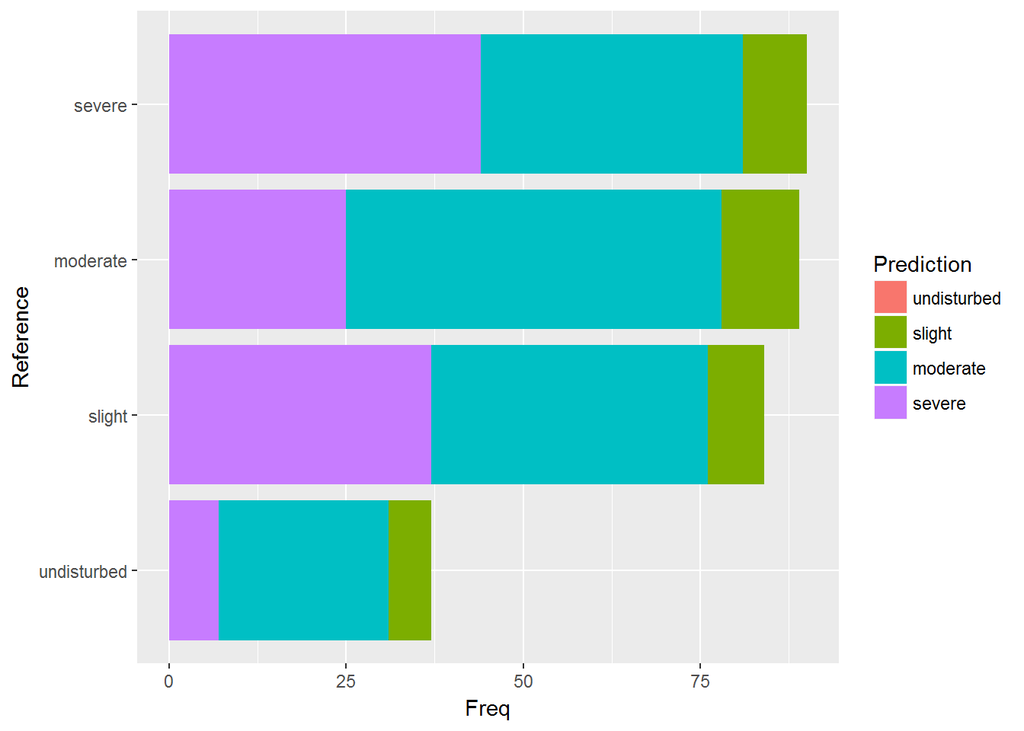

```r
test <- as.data.frame(cm$table)

ggplot(test, aes(x = Reference, y = Freq, fill = Prediction)) +
  geom_bar(stat = "identity") +
  coord_flip()
```

The accuracy of the current ArcSIE model appears to be low, according to several metrics. None of the classes achieve a positive predictive value of > 50% for the reference data.

## 5.1 Boxplots

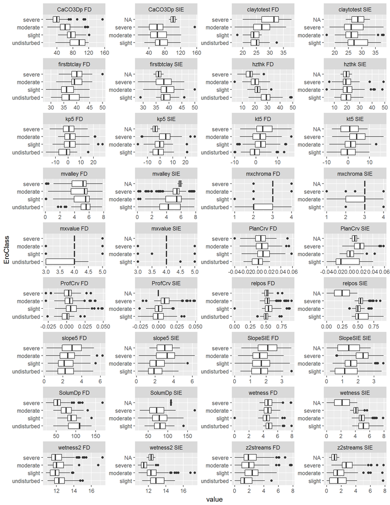

```r
soil_vals <- c("hzthk", "SolumDp", "CaCO3Dp", "claytotest", "firstbtclay", "mxvalue", "mxchroma")
geo_vals1 <- c("SlopeSIE", "ProfCrv", "PlanCrv", "relpos", "wetness")
geo_vals2 <- c("slope5", "kt5", "kp5", "z2streams", "wetness2", "mvalley")

vals <- c(soil_vals, geo_vals1, geo_vals2)

gw_lo1 <- melt(gw, id.vars = "EroClassFD", measure.vars = vals)
gw_lo2 <- melt(gw, id.vars = "EroClassSIE", measure.vars = vals)

names(gw_lo1)[1] <- "EroClass"
gw_lo1$method <- "FD"
names(gw_lo2)[1] <- "EroClass"
gw_lo2$method <- "SIE"
gw_lo <- rbind(gw_lo1, gw_lo2)

ggplot(gw_lo, aes(x = EroClass, y = value)) +
  geom_boxplot() +
  facet_wrap(~ paste(variable, method), scales="free", ncol = 4) +
  coord_flip()
```

An exploratory analysis shows a considerable amount of overlap exists between the field determined (FD) erosion classes and measurable soil properties. In comparison the FD and SIE (Soil Inference Engine) erosion classes show different patterns within the boxplots, further suggesting that the SIE classes aren’t capturing the field observations accurately.

## 5.2 Scatterplots

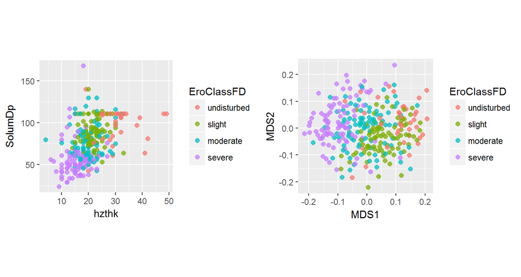

```r
soil_vals2 <- c("hzthk", "SolumDp", "CaCO3Dp", "claytotest", "firstbtclay") # excluded color, only observed a narrow range thus small differences swamp everthing else
vals <- c(soil_vals2, geo_vals2)

test <- gw[, vals]
test_d <- daisy(scale(test), metric = "gower")
test_mds <- metaMDS(test_d, distance = "gower", autotransform = FALSE, trace = FALSE)
test_pts <- cbind(as.data.frame(test_mds$points), EroClassFD = gw$EroClassFD)

g1 <- ggplot(gw, aes(x = hzthk, y = SolumDp, color = EroClassFD)) +
  geom_point(cex = 2, alpha = 0.75) +
  theme(aspect.ratio = 1)
g2 <- ggplot(test_pts, aes(x = MDS1, y = MDS2, color = EroClassFD)) +
  geom_point(cex = 2, alpha = 0.75) +
  theme(aspect.ratio = 1)
grid.arrange(g1, g2, ncol = 2)
```

# 6 Hierachical Clusters

In order to see if more separation can be achieved amongst the erosion classes a hierachical classifition was peformed. Four unsupervised classes were chosen and manually matched to the FD classes.

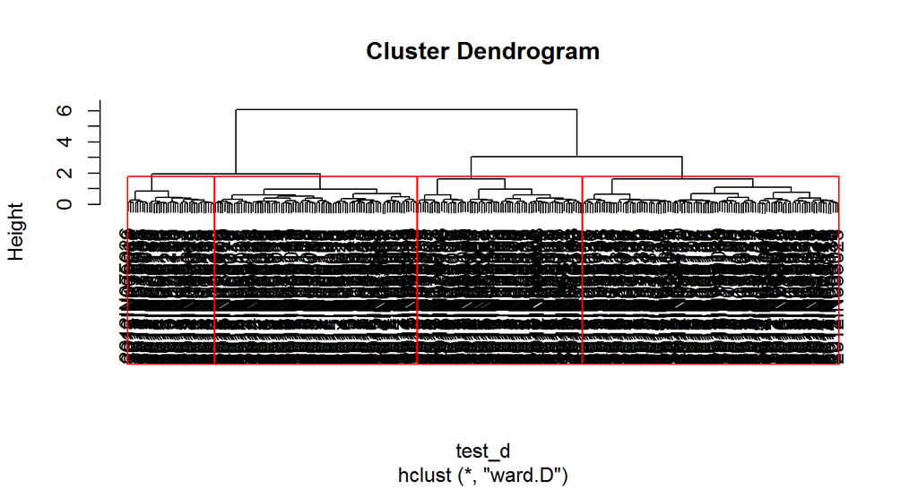

```r
test_c <- hclust(test_d, method = "ward")
plot(test_c, labels = gw$upedonid)
rect.hclust(test_c, k = 4)
```

```r
clusters <- cbind(gw,
                  test_pts[, 1:2],
                  clusters = factor(cutree(test_c, k = 4),
                                    levels = c(2, 3, 1, 4),
                                    labels = ero_labels
                                    )
                  )

xtabs(~ EroClassFD + clusters, data = clusters)
```

```
##              clusters
## EroClassFD    undisturbed slight moderate severe
##   undisturbed          14     14        6      3
##   slight               12     48       22      3
##   moderate              7     24       25     34
##   severe                4      0       17     69
```

## 6.1 Scatter Plots

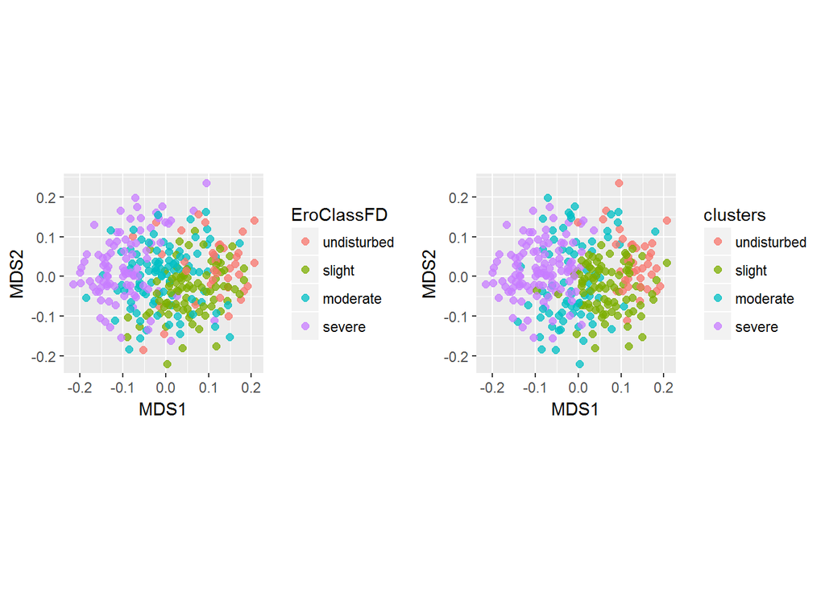

```r
g1 <- ggplot(clusters, aes(x = MDS1, y = MDS2, col = EroClassFD)) +
  geom_point(cex = 2, alpha = 0.75) +
  theme(aspect.ratio = 1)
g2 <- ggplot(clusters, aes(x = MDS1, y = MDS2, col = clusters), main = "test") +
  geom_point(cex = 2, alpha = 0.75) +
  theme(aspect.ratio = 1)
grid.arrange(g1, g2, ncol = 2)
```

In comparison the hierarchical clusters have less overlap when viewed along the multidimensional scaled axes, but still does not seem to separate the moderate class.

## 6.2 Box Plots

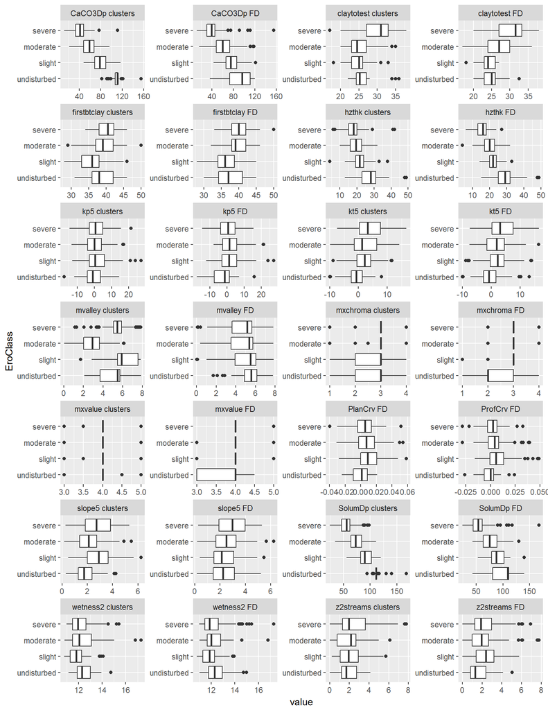

```r
gw_lo3 <- melt(clusters, id.vars = "clusters", measure.vars = c(soil_vals, geo_vals2))

names(gw_lo3)[1] <- "EroClass"
gw_lo3$method <- "clusters"
gw_lo1 <- subset(gw_lo1, ! variable %in%  c("relpos", "wetness", "SlopeSIE"))
gw_lo <- rbind(gw_lo1, gw_lo3)

ggplot(gw_lo, aes(x = EroClass, y = value)) +
  geom_boxplot() +
  facet_wrap(~ paste(variable, method), scales="free", ncol = 4) +
  coord_flip()
```

# 7 Statistical Modeling

Below several statistical models are evaluated to see if a more accurate model can be developed.

## 7.1 Classification Trees

### 7.1.1 FD Classes vs Soil Properties

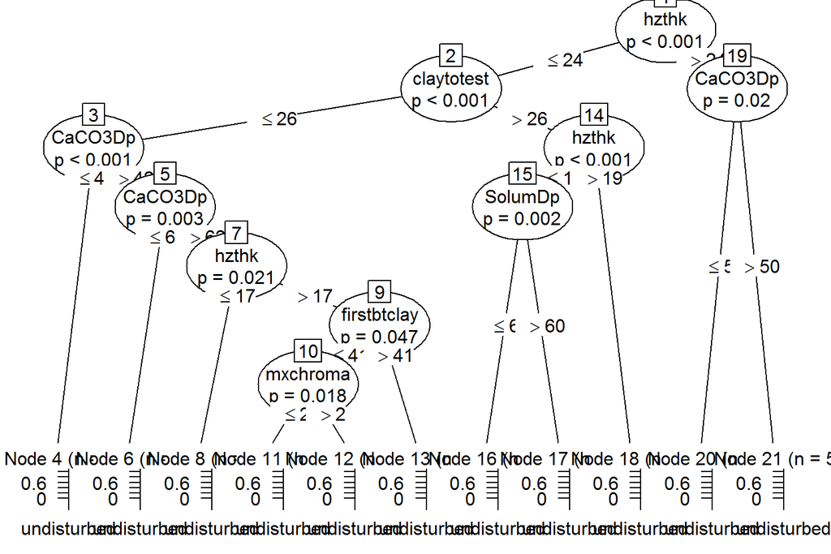

```r
clusters <- subset(clusters, !is.na(EroClassFD))

test1 <- ctree(EroClassFD ~ ., data = clusters[, c("EroClassFD", soil_vals)])
plot(test1)
```

```r
confusionMatrix(data = predict(test1, type = "response"), reference = clusters$EroClassFD)
```

```
## Confusion Matrix and Statistics
##
##              Reference
## Prediction    undisturbed slight moderate severe
##   undisturbed          30     20       11      2
##   slight                3     48        5      1
##   moderate              3     17       67     27
##   severe                1      0        7     60
##
## Overall Statistics
##
##                Accuracy : 0.6788
##                  95% CI : (0.6229, 0.7311)
##     No Information Rate : 0.298
##     P-Value [Acc > NIR] : < 2.2e-16
##
##                   Kappa : 0.567
##  Mcnemar's Test P-Value : 1.943e-06
##
## Statistics by Class:
##
##                      Class: undisturbed Class: slight Class: moderate
## Sensitivity                     0.81081        0.5647          0.7444
## Specificity                     0.87547        0.9585          0.7783
## Pos Pred Value                  0.47619        0.8421          0.5877
## Neg Pred Value                  0.97071        0.8490          0.8777
## Prevalence                      0.12252        0.2815          0.2980
## Detection Rate                  0.09934        0.1589          0.2219
## Detection Prevalence            0.20861        0.1887          0.3775
## Balanced Accuracy               0.84314        0.7616          0.7614
##                      Class: severe
## Sensitivity                 0.6667
## Specificity                 0.9623
## Pos Pred Value              0.8824
## Neg Pred Value              0.8718
## Prevalence                  0.2980
## Detection Rate              0.1987
## Detection Prevalence        0.2252
## Balanced Accuracy           0.8145
```

### 7.1.2 Clusters vs Soil Properties

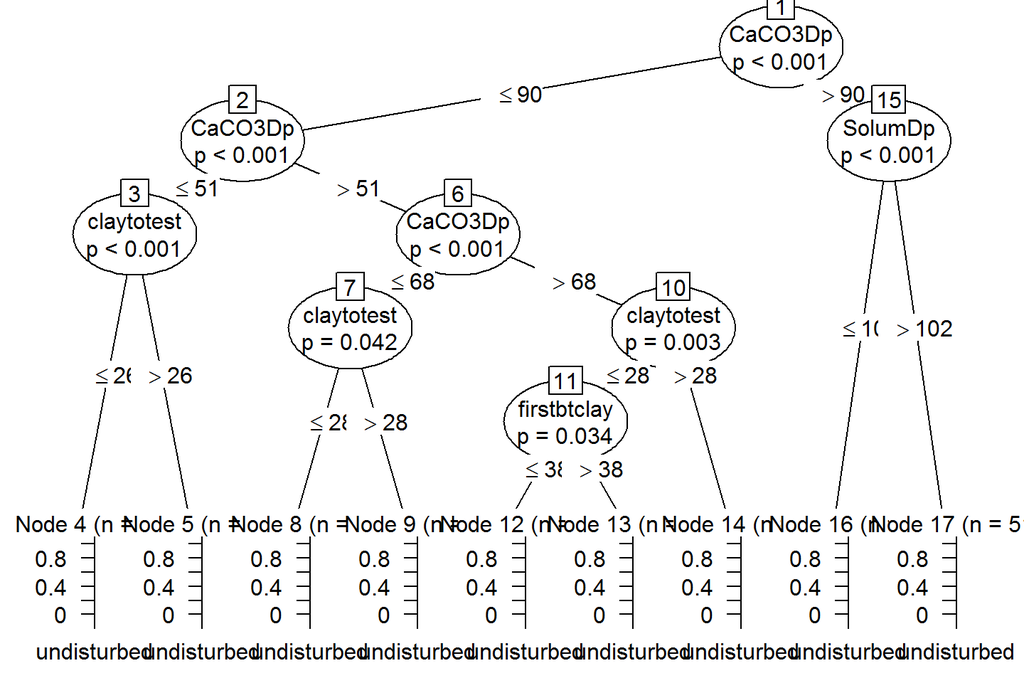

```r
test2 <- ctree(clusters ~ ., data = clusters[, c("clusters", soil_vals)])
plot(test2)
```

```r
confusionMatrix(data = predict(test2, type = "response"), reference = clusters$clusters)
```

```
## Confusion Matrix and Statistics
##
##              Reference
## Prediction    undisturbed slight moderate severe
##   undisturbed          36     14        1      0
##   slight                1     52       10      2
##   moderate              0     19       48     23
##   severe                0      1       11     84
##
## Overall Statistics
##
##                Accuracy : 0.7285
##                  95% CI : (0.6746, 0.7778)
##     No Information Rate : 0.3609
##     P-Value [Acc > NIR] : < 2.2e-16
##
##                   Kappa : 0.6302
##  Mcnemar's Test P-Value : NA
##
## Statistics by Class:
##
##                      Class: undisturbed Class: slight Class: moderate
## Sensitivity                      0.9730        0.6047          0.6857
## Specificity                      0.9434        0.9398          0.8190
## Pos Pred Value                   0.7059        0.8000          0.5333
## Neg Pred Value                   0.9960        0.8565          0.8962
## Prevalence                       0.1225        0.2848          0.2318
## Detection Rate                   0.1192        0.1722          0.1589
## Detection Prevalence             0.1689        0.2152          0.2980
## Balanced Accuracy                0.9582        0.7722          0.7523
##                      Class: severe
## Sensitivity                 0.7706
## Specificity                 0.9378
## Pos Pred Value              0.8750
## Neg Pred Value              0.8786
## Prevalence                  0.3609
## Detection Rate              0.2781
## Detection Prevalence        0.3179
## Balanced Accuracy           0.8542
```

### 7.1.3 FD Classes vs DEM Derivatives

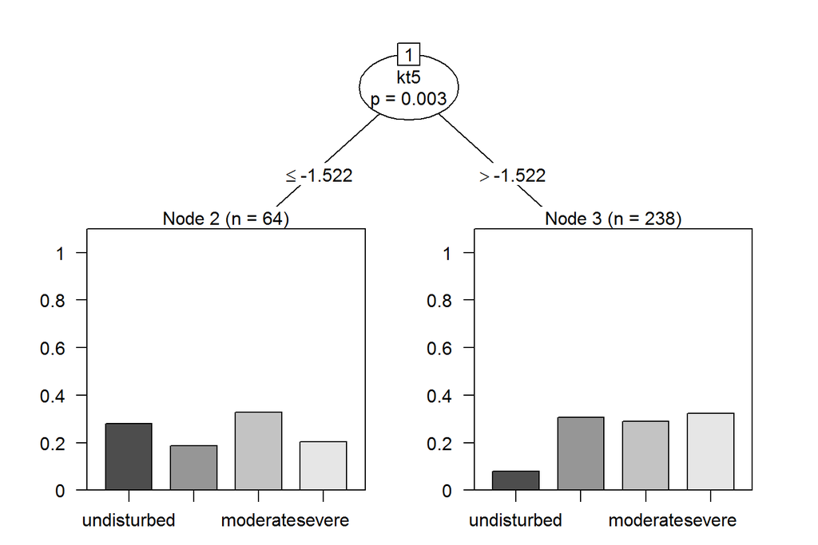

```r
test3 <- ctree(EroClassFD ~ ., data = clusters[, c("EroClassFD", geo_vals2)])
plot(test3)
```

```r
confusionMatrix(data = predict(test3, type = "response"), reference = clusters$EroClassFD)
```

```
## Confusion Matrix and Statistics
##
##              Reference
## Prediction    undisturbed slight moderate severe
##   undisturbed           0      0        0      0
##   slight                0      0        0      0
##   moderate             18     12       21     13
##   severe               19     73       69     77
##
## Overall Statistics
##
##                Accuracy : 0.3245
##                  95% CI : (0.272, 0.3805)
##     No Information Rate : 0.298
##     P-Value [Acc > NIR] : 0.1724
##
##                   Kappa : 0.0377
##  Mcnemar's Test P-Value : NA
##
## Statistics by Class:
##
##                      Class: undisturbed Class: slight Class: moderate
## Sensitivity                      0.0000        0.0000         0.23333
## Specificity                      1.0000        1.0000         0.79717
## Pos Pred Value                      NaN           NaN         0.32812
## Neg Pred Value                   0.8775        0.7185         0.71008
## Prevalence                       0.1225        0.2815         0.29801
## Detection Rate                   0.0000        0.0000         0.06954
## Detection Prevalence             0.0000        0.0000         0.21192
## Balanced Accuracy                0.5000        0.5000         0.51525
##                      Class: severe
## Sensitivity                 0.8556
## Specificity                 0.2406
## Pos Pred Value              0.3235
## Neg Pred Value              0.7969
## Prevalence                  0.2980
## Detection Rate              0.2550
## Detection Prevalence        0.7881
## Balanced Accuracy           0.5481
```

```r
test3 <- cforest(as.factor(EroClassFD) ~ ., data = gw[, c("EroClassFD", geo_vals2)])
varimp(test3)
```

```
##       slope5          kt5          kp5    z2streams     wetness2
## 0.0344684685 0.0179819820 0.0060000000 0.0039819820 0.0196756757
##      mvalley
## 0.0006306306
```

```r
confusionMatrix(data = predict(test3, type = "response", OOB = TRUE), reference = gw$EroClassFD)
```

```
## Confusion Matrix and Statistics
##
##              Reference
## Prediction    undisturbed slight moderate severe
##   undisturbed           2      8        5      4
##   slight                7     26       24     18
##   moderate             16     28       36     17
##   severe               12     23       25     51
##
## Overall Statistics
##
##                Accuracy : 0.3808
##                  95% CI : (0.3258, 0.4382)
##     No Information Rate : 0.298
##     P-Value [Acc > NIR] : 0.001259
##
##                   Kappa : 0.1366
##  Mcnemar's Test P-Value : 0.056213
##
## Statistics by Class:
##
##                      Class: undisturbed Class: slight Class: moderate
## Sensitivity                    0.054054       0.30588          0.4000
## Specificity                    0.935849       0.77419          0.7123
## Pos Pred Value                 0.105263       0.34667          0.3711
## Neg Pred Value                 0.876325       0.74009          0.7366
## Prevalence                     0.122517       0.28146          0.2980
## Detection Rate                 0.006623       0.08609          0.1192
## Detection Prevalence           0.062914       0.24834          0.3212
## Balanced Accuracy              0.494952       0.54004          0.5561
##                      Class: severe
## Sensitivity                 0.5667
## Specificity                 0.7170
## Pos Pred Value              0.4595
## Neg Pred Value              0.7958
## Prevalence                  0.2980
## Detection Rate              0.1689
## Detection Prevalence        0.3675
## Balanced Accuracy           0.6418
```

### 7.1.4 Clusters vs DEM Derivatives

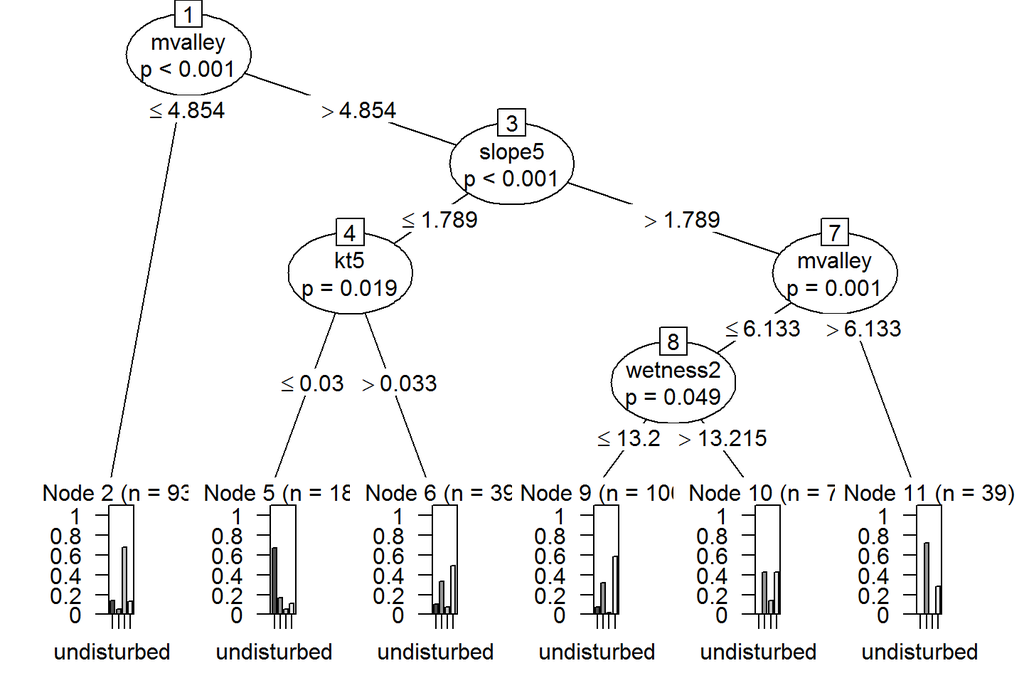

```r
test4 <- ctree(clusters ~ ., data = clusters[, c("clusters", geo_vals2)])
plot(test4)
```

```r
confusionMatrix(data = predict(test4, type = "response"), reference = clusters$clusters)
```

```
## Confusion Matrix and Statistics
##
##              Reference
## Prediction    undisturbed slight moderate severe
##   undisturbed          12      3        1      2
##   slight                0     31        1     14
##   moderate             13      5       63     12
##   severe               12     47        5     81
##
## Overall Statistics
##
##                Accuracy : 0.6192
##                  95% CI : (0.5618, 0.6742)
##     No Information Rate : 0.3609
##     P-Value [Acc > NIR] : < 2.2e-16
##
##                   Kappa : 0.4596
##  Mcnemar's Test P-Value : 7.988e-08
##
## Statistics by Class:
##
##                      Class: undisturbed Class: slight Class: moderate
## Sensitivity                     0.32432        0.3605          0.9000
## Specificity                     0.97736        0.9306          0.8707
## Pos Pred Value                  0.66667        0.6739          0.6774
## Neg Pred Value                  0.91197        0.7852          0.9665
## Prevalence                      0.12252        0.2848          0.2318
## Detection Rate                  0.03974        0.1026          0.2086
## Detection Prevalence            0.05960        0.1523          0.3079
## Balanced Accuracy               0.65084        0.6455          0.8853
##                      Class: severe
## Sensitivity                 0.7431
## Specificity                 0.6684
## Pos Pred Value              0.5586
## Neg Pred Value              0.8217
## Prevalence                  0.3609
## Detection Rate              0.2682
## Detection Prevalence        0.4801
## Balanced Accuracy           0.7058
```

```r
test4 <- cforest(clusters ~ ., data = clusters[, c("clusters", geo_vals2)])
varimp(test4)
```

```
##        slope5           kt5           kp5     z2streams      wetness2
##  0.0199099099  0.0208108108 -0.0001261261  0.0002522523  0.0097117117
##       mvalley
##  0.2005225225
```

```r
confusionMatrix(data = predict(test4, type = "response", OOB=TRUE), reference = clusters$clusters)
```

```
## Confusion Matrix and Statistics
##
##              Reference
## Prediction    undisturbed slight moderate severe
##   undisturbed           9      1        3      4
##   slight                3     37        1     22
##   moderate             13      5       61     12
##   severe               12     43        5     71
##
## Overall Statistics
##
##                Accuracy : 0.5894
##                  95% CI : (0.5316, 0.6454)
##     No Information Rate : 0.3609
##     P-Value [Acc > NIR] : 6.22e-16
##
##                   Kappa : 0.4195
##  Mcnemar's Test P-Value : 0.0006228
##
## Statistics by Class:
##
##                      Class: undisturbed Class: slight Class: moderate
## Sensitivity                     0.24324        0.4302          0.8714
## Specificity                     0.96981        0.8796          0.8707
## Pos Pred Value                  0.52941        0.5873          0.6703
## Neg Pred Value                  0.90175        0.7950          0.9573
## Prevalence                      0.12252        0.2848          0.2318
## Detection Rate                  0.02980        0.1225          0.2020
## Detection Prevalence            0.05629        0.2086          0.3013
## Balanced Accuracy               0.60653        0.6549          0.8711
##                      Class: severe
## Sensitivity                 0.6514
## Specificity                 0.6891
## Pos Pred Value              0.5420
## Neg Pred Value              0.7778
## Prevalence                  0.3609
## Detection Rate              0.2351
## Detection Prevalence        0.4338
## Balanced Accuracy           0.6702
```

## 7.2 Soil series and phase

Try and model the soil components and phases separately. The data is highly unbalanced. Create separate logistic regression models for similar minor components.

```r
#gw$weights <- ifelse(gw$soilname == "Glynwood", 0.1, 1)
gw$gw_severe <- ifelse(gw$soilname3 == "Glynwood-severe", TRUE, FALSE)

test4 <- cforest(as.factor(gw_severe) ~ elev + slope5 + kt5 + kp5 + wetness2 + mvalley + z2streams, data = gw)
sort(varimp(test4), decreasing = TRUE)
```

```
##        elev      slope5         kt5    wetness2   z2streams         kp5
## 0.028558559 0.026126126 0.016108108 0.011909910 0.002558559 0.002252252
##     mvalley
## 0.002144144
```

```r
confusionMatrix(data = predict(test4, type = "response", OOB = TRUE), reference = gw$gw_severe, positive = "TRUE")
```

```
## Confusion Matrix and Statistics
##
##           Reference
## Prediction FALSE TRUE
##      FALSE   198   66
##      TRUE     14   24
##
##                Accuracy : 0.7351
##                  95% CI : (0.6815, 0.784)
##     No Information Rate : 0.702
##     P-Value [Acc > NIR] : 0.1152
##
##                   Kappa : 0.2406
##  Mcnemar's Test P-Value : 1.184e-08
##
##             Sensitivity : 0.26667
##             Specificity : 0.93396
##          Pos Pred Value : 0.63158
##          Neg Pred Value : 0.75000
##              Prevalence : 0.29801
##          Detection Rate : 0.07947
##    Detection Prevalence : 0.12583
##       Balanced Accuracy : 0.60031
##
##        'Positive' Class : TRUE
##
```

```r
test3 <- glm(as.factor(gw_severe) ~ elev + slope5 + kt5, data = gw, family = "binomial", na.action = na.exclude)
confusionMatrix(data = predict(test3, type = "response") > 0.4, reference = gw$gw_severe, positive = "TRUE")
```

```
## Confusion Matrix and Statistics
##
##           Reference
## Prediction FALSE TRUE
##      FALSE   174   49
##      TRUE     35   40
##
##                Accuracy : 0.7181
##                  95% CI : (0.6634, 0.7685)
##     No Information Rate : 0.7013
##     P-Value [Acc > NIR] : 0.2865
##
##                   Kappa : 0.2953
##  Mcnemar's Test P-Value : 0.1561
##
##             Sensitivity : 0.4494
##             Specificity : 0.8325
##          Pos Pred Value : 0.5333
##          Neg Pred Value : 0.7803
##              Prevalence : 0.2987
##          Detection Rate : 0.1342
##    Detection Prevalence : 0.2517
##       Balanced Accuracy : 0.6410
##
##        'Positive' Class : TRUE
##
```

```r
summary(test3)
```

```
##
## Call:
## glm(formula = as.factor(gw_severe) ~ elev + slope5 + kt5, family = "binomial",
##     data = gw, na.action = na.exclude)
##
## Deviance Residuals:
##     Min       1Q   Median       3Q      Max
## -1.5512  -0.8366  -0.6028   1.0314   2.4255
##
## Coefficients:
##              Estimate Std. Error z value Pr(>|z|)
## (Intercept) -8.953655   2.044889  -4.379 1.19e-05 ***
## elev         0.024425   0.007071   3.455 0.000551 ***
## slope5       0.388811   0.109621   3.547 0.000390 ***
## kt5          0.089968   0.027948   3.219 0.001286 **
## ---
## Signif. codes:  0 '***' 0.001 '**' 0.01 '*' 0.05 '.' 0.1 ' ' 1
##
## (Dispersion parameter for binomial family taken to be 1)
##
##     Null deviance: 363.39  on 297  degrees of freedom
## Residual deviance: 327.73  on 294  degrees of freedom
##   (4 observations deleted due to missingness)
## AIC: 335.73
##
## Number of Fisher Scoring iterations: 4
```

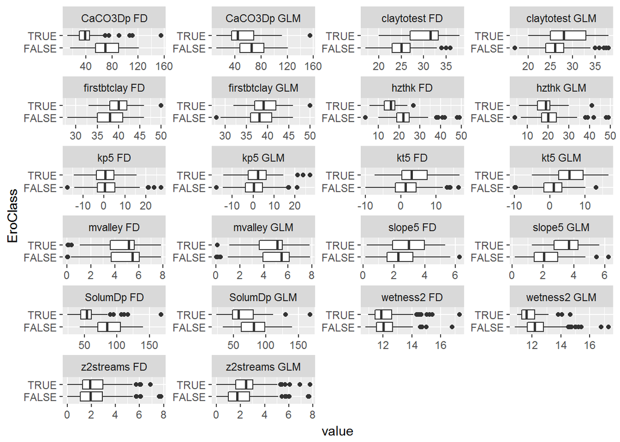

```r
gw$predicted <- predict(test3, type = "response") > 0.4
gw_lo1 <- melt(gw, id.vars = "gw_severe", measure.vars = vals)
gw_lo2 <- melt(gw, id.vars = "predicted", measure.vars = vals)
gw_lo2 <- na.exclude(gw_lo2)

names(gw_lo1)[1] <- "EroClass"
gw_lo1$method <- "FD"
names(gw_lo2)[1] <- "EroClass"
gw_lo2$method <- "GLM"
gw_lo <- rbind(gw_lo1, gw_lo2)

ggplot(gw_lo, aes(x = EroClass, y = value)) +
  geom_boxplot() +
  facet_wrap(~ paste(variable, method), scales="free", ncol = 4) +
  coord_flip()
```

```r
predfun <- function(model, data) {
  v <- predict(model, data, type = "response")
  cbind(
    p = as.vector(v$fit)
    )
}
r <- predict(rs10m, test3, fun = predfun, index = 1:2, progress = "text")
writeRaster(r[[1]], "C:/workspace/severe_erosion.tif", overwrite = TRUE, progress = "text")

r <-predict(rs10m, test4, type='response', progress='text')
writeRaster(r[[1]], "C:/workspace/severe_erosion_cf.tif", overwrite = TRUE, progress = "text")
```

# 8 Summary

- If disaggregating the SSURGO polygons is deemed impractical or inaccurate, re-label the Glynwood B-slope map units (e.g. severely eroded) to the appropriate map unit concept (e.g moderately eroded).
- Evaluate ways to improve the accuracy of the ArcSIE model, or test alternative models such as random forests.
- Conduct a field review May 15th (?) to evaluate the erosion phase concepts and spatial model.
- Evaluate the effect of lumping erosion classes (e.g. slightly and moderately).
- Access yield data from a producer in order to validate the hypothesis that the erosion phases help explain yield variability.